# Task 1 - Retail Strategy and Analytics

Yixi Deng

7/20/2021

## Load required libraries and datasets

```r
#### Load required libraries
library(data.table)
library(ggplot2)
library(ggmosaic)
library(readr)
library(dbplyr)
library(dplyr)
#### Point the filePath to where you have downloaded the datasets to and
#### assign the data files to data.tables
filePath <- "C:/Users/User/Desktop/JobSeeking/Project/Forage/Quantium/task1/"
transactionData <- fread(paste0(filePath,"QVI_transaction_data.csv"))
customerData <- fread(paste0(filePath,"QVI_purchase_behaviour.csv"))
```

## Exploratory data analysis

The first step in any analysis is to first understand the data. Let’s take a look at each of the datasets provided.

### Examining transaction data

We can use `str()` to look at the format of each column and see a sample of the data. As we have read in the dataset as a `data.table` object, we can also run `transactionData` in the console to see a sample of the data or use `head(transactionData)` to look at the first 10 rows.

Let’s check if columns we would expect to be numeric are in numeric form and date columns are in date format.

```r
#### Examine transaction data
str(transactionData)
```

```
## Classes 'data.table' and 'data.frame': 264836 obs. of 8 variables:
## $ DATE : int 43390 43599 43605 43329 43330 43604 43601 43601 43332 43330 ...
## $ STORE_NBR : int 1 1 1 2 2 4 4 4 5 7 ...
## $ LYLTY_CARD_NBR: int 1000 1307 1343 2373 2426 4074 4149 4196 5026 7150 ...
## $ TXN_ID : int 1 348 383 974 1038 2982 3333 3539 4525 6900 ...
## $ PROD_NBR : int 5 66 61 69 108 57 16 24 42 52 ...
## $ PROD_NAME : chr "Natural Chip Compny SeaSalt175g" "CCs Nacho Cheese 175g"
"Smiths Crinkle Cut Chips Chicken 170g" "Smiths Chip Thinly S/Cream&Onion 175g"
...
## $ PROD_QTY : int 2 3 2 5 3 1 1 1 1 2 ...
## $ TOT_SALES : num 6 6.3 2.9 15 13.8 5.1 5.7 3.6 3.9 7.2 ...
## - attr(*, ".internal.selfref")=<externalptr>
```

We can see that the date column is in an integer format. Let’s change this to a date format.

```r
#### Convert DATE column to a date format
#### A quick search online tells us that CSV and Excel integer dates begin on 30
#### Dec 1899
transactionData$DATE <- as.Date(transactionData$DATE, origin = "1899-12-30")
```

We should check that we are looking at the right products by examining PROD_NAME.

```r
#### Examine PROD_NAME
transactionData[,.N,PROD_NAME]
```

| PROD_NAME | N |
| --- | --- |
| Natural Chip Compny SeaSalt175g | 1468 |
| CCs Nacho Cheese 175g | 1498 |
| Smiths Crinkle Cut Chips Chicken 170g | 1484 |
| Smiths Chip Thinly S/Cream&Onion 175g | 1473 |
| Kettle Tortilla ChpsHny&Jlpno Chili 150g | 3296 |
| Old El Paso Salsa Dip Tomato Mild 300g | 3085 |
| Smiths Crinkle Chips Salt & Vinegar 330g | 3197 |
| Grain Waves Sweet Chilli 210g | 3167 |
| Doritos Corn Chip Mexican Jalapeno 150g | 3204 |
| Grain Waves Sour Cream&Chives 210G | 3105 |

[output cut: 104 more lines]

Looks like we are definitely looking at potato chips but how can we check that these are all chips? We can do some basic text analysis by summarising the individual words in the product name.

```r
#### Examine the words in PROD_NAME to see if there are any incorrect entries
#### such as products that are not chips
productWords <- data.table(unlist(strsplit(unique(transactionData[, PROD_NAME]), "
")))
setnames(productWords, 'words')
```

As we are only interested in words that will tell us if the product is chips or not, let’s remove all words with digits and special characters such as ‘&’ from our set of product words. We can do this using `grepl()`.

```r
#### Removing digits
for (i in 1:nrow(productWords)) {
  productWords[i] <- gsub("[[:digit:]]+[[:alnum:]]","",productWords[i])
}

#### Removing special characters
for (i in 1:nrow(productWords)) {
  productWords[i] <- gsub("[[:punct:]]+","",productWords[i])
}

#### Let's look at the most common words by counting the number of times a word
#### appears and
#### sorting them by this frequency in order of highest to lowest frequency
words.freq <- as.data.frame(table(unlist(strsplit(productWords$words," "))))
setnames(words.freq,c("words","N"))
words.freq <- words.freq[-1,]
words.freq <- words.freq[order(-words.freq$N),]
head(words.freq)
```

|  | words | N |
| --- | --- | --- |
| 35 | Chips | 21 |
| 148 | Smiths | 16 |
| 54 | Crinkle | 14 |
| 61 | Cut | 14 |
| 88 | Kettle | 13 |
| 23 | Cheese | 12 |

```r
tail(words.freq)
```

|  | words | N |
| --- | --- | --- |
| 183 | Truffle | 1 |
| 186 | Veg | 1 |
| 188 | Vinegr | 1 |
| 189 | Vingar | 1 |
| 191 | Whlegrn | 1 |
| 192 | Whlgrn | 1 |

There are salsa products in the dataset but we are only interested in the chips category, so let’s remove these.

```r
#### Remove salsa products
transactionData[, SALSA := grepl("salsa", tolower(PROD_NAME))]
transactionData <- transactionData[SALSA == FALSE, ][, SALSA := NULL]
```

Next, we can use `summary()` to check summary statistics such as mean, min and max values for each feature to see if there are any obvious outliers in the data and if there are any nulls in any of the columns (`NA's : number of nulls` will appear in the output if there are any nulls).

```r
#### Summarise the data to check for nulls and possible outliers
summary(transactionData)
```

```
##       DATE              STORE_NBR     LYLTY_CARD_NBR        TXN_ID
##  Min.   :2018-07-01   Min.   :  1.0   Min.   :   1000   Min.   :      1
##  1st Qu.:2018-09-30   1st Qu.: 70.0   1st Qu.:  70015   1st Qu.:  67569
##  Median :2018-12-30   Median :130.0   Median : 130367   Median : 135183
##  Mean   :2018-12-30   Mean   :135.1   Mean   : 135531   Mean   : 135131
##  3rd Qu.:2019-03-31   3rd Qu.:203.0   3rd Qu.: 203084   3rd Qu.: 202654
##  Max.   :2019-06-30   Max.   :272.0   Max.   :2373711   Max.   :2415841
##     PROD_NBR       PROD_NAME            PROD_QTY         TOT_SALES
##  Min.   :  1.00   Length:246742      Min.   :  1.000   Min.   :  1.700
##  1st Qu.: 26.00   Class :character   1st Qu.:  2.000   1st Qu.:  5.800
##  Median : 53.00   Mode  :character   Median :  2.000   Median :  7.400
##  Mean   : 56.35                      Mean   :  1.908   Mean   :  7.321
##  3rd Qu.: 87.00                      3rd Qu.:  2.000   3rd Qu.:  8.800
##  Max.   :114.00                      Max.   :200.000   Max.   :650.000
```

There are no nulls in the columns but product quantity appears to have an outlier which we should investigate further. Let’s investigate further the case where 200 packets of chips are bought in one transaction.

```r
#### Filter the dataset to find the outlier
prodQty.outlier <- transactionData[PROD_QTY == 200, ]
prodQty.outlier
```

| DATE | STORE_NBR | LYLTY_CARD_NBR | TXN_ID | PROD_NBR | PROD_NAME | PROD_QTY | TOT_SALES |
| --- | --- | --- | --- | --- | --- | --- | --- |
| 2018-08-19 | 226 | 226000 | 226201 | 4 | Dorito Corn Chp Supreme 380g | 200 | 650 |
| 2019-05-20 | 226 | 226000 | 226210 | 4 | Dorito Corn Chp Supreme 380g | 200 | 650 |

There are two transactions where 200 packets of chips are bought in one transaction and both of these transactions were by the same customer.

```r
#### Let's see if the customer has had other transactions
transactionData[LYLTY_CARD_NBR == prodQty.outlier$LYLTY_CARD_NBR[1],]
```

| DATE | STORE_NBR | LYLTY_CARD_NBR | TXN_ID | PROD_NBR | PROD_NAME | PROD_QTY | TOT_SALES |
| --- | --- | --- | --- | --- | --- | --- | --- |
| 2018-08-19 | 226 | 226000 | 226201 | 4 | Dorito Corn Chp Supreme 380g | 200 | 650 |
| 2019-05-20 | 226 | 226000 | 226210 | 4 | Dorito Corn Chp Supreme 380g | 200 | 650 |

It looks like this customer has only had the two transactions over the year and is not an ordinary retail customer. The customer might be buying chips for commercial purposes instead. We’ll remove this loyalty card number from further analysis.

```r
#### Filter out the customer based on the loyalty card number
transactionData <- transactionData[LYLTY_CARD_NBR != prodQty.outlier$LYLTY_CARD_NBR[1],]

#### Re-examine transaction data
summary(transactionData)
```

```
##       DATE              STORE_NBR     LYLTY_CARD_NBR        TXN_ID
##  Min.   :2018-07-01   Min.   :  1.0   Min.   :   1000   Min.   :      1
##  1st Qu.:2018-09-30   1st Qu.: 70.0   1st Qu.:  70015   1st Qu.:  67569
##  Median :2018-12-30   Median :130.0   Median : 130367   Median : 135182
##  Mean   :2018-12-30   Mean   :135.1   Mean   : 135530   Mean   : 135130
##  3rd Qu.:2019-03-31   3rd Qu.:203.0   3rd Qu.: 203083   3rd Qu.: 202652
##  Max.   :2019-06-30   Max.   :272.0   Max.   :2373711   Max.   :2415841
##     PROD_NBR       PROD_NAME            PROD_QTY       TOT_SALES
##  Min.   :  1.00   Length:246740      Min.   :1.000   Min.   : 1.700
##  1st Qu.: 26.00   Class :character   1st Qu.:2.000   1st Qu.: 5.800
##  Median : 53.00   Mode  :character   Median :2.000   Median : 7.400
##  Mean   : 56.35                      Mean   :1.906   Mean   : 7.316
##  3rd Qu.: 87.00                      3rd Qu.:2.000   3rd Qu.: 8.800
##  Max.   :114.00                      Max.   :5.000   Max.   :29.500
```

That’s better. Now, let’s look at the number of transaction lines over time to see if there are any obvious data issues such as missing data.

```r
#### Count the number of transactions by date
transactions_by_day <- as.data.frame(table(transactionData$DATE))
setnames(transactions_by_day, c('DATE','N'))
head(transactions_by_day[order(-transactions_by_day$N),])
```

|  | DATE | N |
| --- | --- | --- |
| 177 | 2018-12-24 | 865 |
| 176 | 2018-12-23 | 853 |
| 175 | 2018-12-22 | 840 |
| 172 | 2018-12-19 | 839 |
| 173 | 2018-12-20 | 808 |
| 171 | 2018-12-18 | 799 |

```r
transactions_by_day$DATE <- as.Date(transactions_by_day$DATE)
```

There’s only 364 rows, meaning only 364 dates which indicates a missing date. Let’s create a sequence of dates from 1 Jul 2018 to 30 Jun 2019 and use this to create a chart of number of transactions over time to find the missing date.

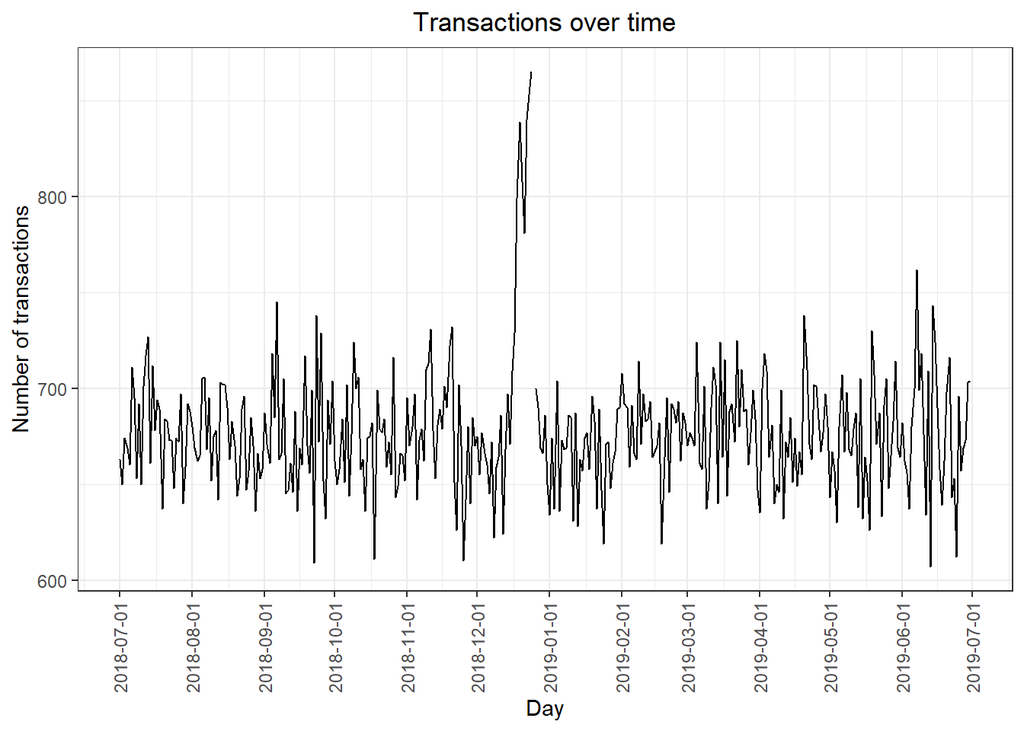

```r
#### Create a sequence of dates and join this the count of transactions by date
start_date <- as.Date("2018-07-01")
range.date <- as.data.frame(seq(start_date, by = "day", length.out = 365))
setnames(range.date,"DATE")
transactions_by_day <- merge(range.date,transactions_by_day, all.x = TRUE)

#### Setting plot themes to format graphs
theme_set(theme_bw())
theme_update(plot.title = element_text(hjust = 0.5))

#### Plot transactions over time
ggplot(transactions_by_day, aes(x = DATE, y = N)) +
geom_line() +
labs(x = "Day", y = "Number of transactions", title = "Transactions over time") +
scale_x_date(breaks = "1 month") +
theme(axis.text.x = element_text(angle = 90, vjust = 0.5))
```

We can see that there is an increase in purchases in December and a break in late December. Let’s zoom in on this.

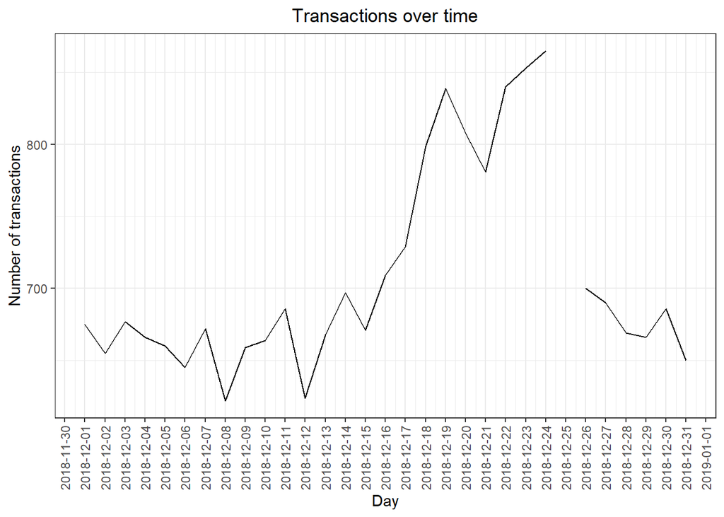

```r
#### Filter to December and look at individual days
theme_set(theme_bw())
theme_update(plot.title = element_text(hjust = 0.5))

#### Plot transactions over time
ggplot(transactions_by_day[month(transactions_by_day$DATE) == 12,],
       aes(x = DATE, y = N)) +
  geom_line() +
  labs(x = "Day", y = "Number of transactions", title = "Transactions over time") +
  scale_x_date(breaks = "1 day") +
  theme(axis.text.x = element_text(angle = 90, vjust = 0.5))
```

We can see that the increase in sales occurs in the lead-up to Christmas and that there are zero sales on Christmas day itself. This is due to shops being closed on Christmas day.

Now that we are satisfied that the data no longer has outliers, we can move on to creating other features such as brand of chips or pack size from PROD_NAME. We will start with pack size.

```r
#### Pack size
#### We can work this out by taking the digits that are in PROD_NAME
transactionData[, PACK_SIZE := parse_number(PROD_NAME)]
#### Always check your output
#### Let's check if the pack sizes look sensible
transactionData[, .N, PACK_SIZE][order(PACK_SIZE)]
```

| PACK_SIZE | N |
| --- | --- |
| 70 | 1507 |
| 90 | 3008 |
| 110 | 22387 |
| 125 | 1454 |
| 134 | 25102 |
| 135 | 3257 |
| 150 | 40203 |
| 160 | 2970 |
| 165 | 15297 |
| 170 | 19983 |

[output cut: 10 more lines]

The largest size is 380g and the smallest size is 70g - seems sensible!

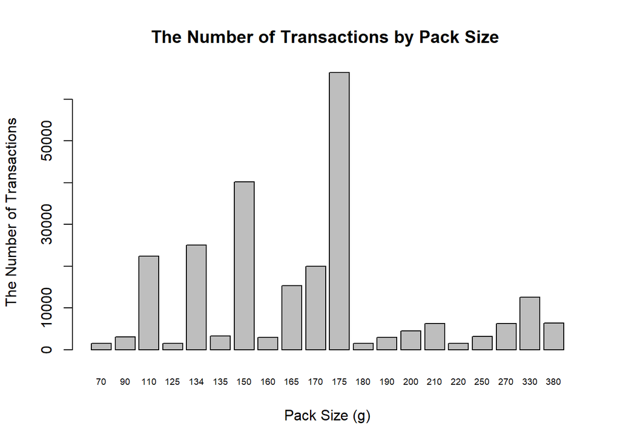

```r
#### Let's plot a histogram of PACK_SIZE since we know that it is a categorical
#### variable and not a continuous variable even though it is numeric.
transaction.pack_size <- transactionData[, .N, PACK_SIZE][order(PACK_SIZE)]
transaction.pack_size$PACK_SIZE <- as.factor(transaction.pack_size$PACK_SIZE)
barplot(transaction.pack_size$N, names.arg = transaction.pack_size$PACK_SIZE,
        cex.names = 0.6,
        xlab = "Pack Size (g)",
        ylab = "The Number of Transactions",
        main = "The Number of Transactions by Pack Size ")
```

Pack sizes created look reasonable. Now to create brands, we can use the first word in PROD_NAME to work out the brand name…

```r
#### Brands
transactionData$BRAND <- gsub("([[:alpha:]]+).*", "\\1", transactionData$PROD_NAME)

#### Checking brands
transactionData[,.N, by = BRAND][order(-N)]
```

| BRAND | N |
| --- | --- |
| Kettle | 41288 |
| Smiths | 27390 |
| Pringles | 25102 |
| Doritos | 22041 |
| Thins | 14075 |
| RRD | 11894 |
| Infuzions | 11057 |
| WW | 10320 |
| Cobs | 9693 |
| Tostitos | 9471 |

[output cut: 18 more lines]

Some of the brand names look like they are of the same brands - such as RED and RRD, which are both Red Rock Deli chips. Let’s combine these together.

```r
#### Clean brand names
transactionData[BRAND == "RED", BRAND := "RRD"]
table(transactionData$BRAND)
```

```
##
##     Burger        CCs    Cheetos   Cheezels       Cobs     Dorito    Doritos
##       1564       4551       2927       4603       9693       3183      22041
##     French      Grain    GrnWves  Infuzions     Infzns     Kettle    Natural
##       1418       6272       1468      11057       3144      41288       6050
##        NCC   Pringles        Red        RRD      Smith     Smiths      Snbts
##       1419      25102       4427      11894       2963      27390       1576
##   Sunbites      Thins   Tostitos   Twisties   Tyrrells Woolworths         WW
##       1432      14075       9471       9454       6442       1516      10320
```

```r
transactionData[BRAND == "Natural", BRAND := "NCC"]
transactionData[BRAND == "Dorito", BRAND := "Doritos"]
transactionData[BRAND == "Infuzions", BRAND := "Infzns"]
transactionData[BRAND == "Red", BRAND := "RRD"]
transactionData[BRAND == "Smith", BRAND := "Smiths"]
transactionData[BRAND == "Sunbites", BRAND := "Snbts"]
transactionData[BRAND == "Woolworths", BRAND := "WW"]
transactionData[BRAND == "Grain", BRAND := "GrnWves"]
#### Check again
table(transactionData$BRAND)
```

```
##
##   Burger      CCs  Cheetos Cheezels     Cobs  Doritos   French  GrnWves
##     1564     4551     2927     4603     9693    25224     1418     7740
##   Infzns   Kettle      NCC Pringles      RRD   Smiths    Snbts    Thins
##    14201    41288     7469    25102    16321    30353     3008    14075
## Tostitos Twisties Tyrrells       WW
##     9471     9454     6442    11836
```

### Examining customer data

Now that we are happy with the transaction dataset, let’s have a look at the customer dataset.

```r
#### Examining customer data
summary(customerData)
```

```
##  LYLTY_CARD_NBR     LIFESTAGE         PREMIUM_CUSTOMER
##  Min.   :   1000   Length:72637       Length:72637
##  1st Qu.:  66202   Class :character   Class :character
##  Median : 134040   Mode  :character   Mode  :character
##  Mean   : 136186
##  3rd Qu.: 203375
##  Max.   :2373711
```

```r
str(customerData)
```

```
## Classes 'data.table' and 'data.frame': 72637 obs. of 3 variables:
## $ LYLTY_CARD_NBR : int 1000 1002 1003 1004 1005 1007 1009 1010 1011 1012 ...
## $ LIFESTAGE : chr "YOUNG SINGLES/COUPLES" "YOUNG SINGLES/COUPLES" "YOUNG
FAMILIES" "OLDER SINGLES/COUPLES" ...
## $ PREMIUM_CUSTOMER: chr "Premium" "Mainstream" "Budget" "Mainstream" ...
## - attr(*, ".internal.selfref")=<externalptr>
```

```r
customerData$LIFESTAGE <- as.factor(customerData$LIFESTAGE)
customerData$PREMIUM_CUSTOMER <- as.factor(customerData$PREMIUM_CUSTOMER)
str(customerData)
```

```
## Classes 'data.table' and 'data.frame': 72637 obs. of 3 variables:
## $ LYLTY_CARD_NBR : int 1000 1002 1003 1004 1005 1007 1009 1010 1011 1012 ...
## $ LIFESTAGE : Factor w/ 7 levels "MIDAGE SINGLES/COUPLES",..: 7 7 6 4 1 7 2
7 4 3 ...
## $ PREMIUM_CUSTOMER: Factor w/ 3 levels "Budget","Mainstream",..: 3 2 1 2 2 1
3 2 2 2 ...
## - attr(*, ".internal.selfref")=<externalptr>
```

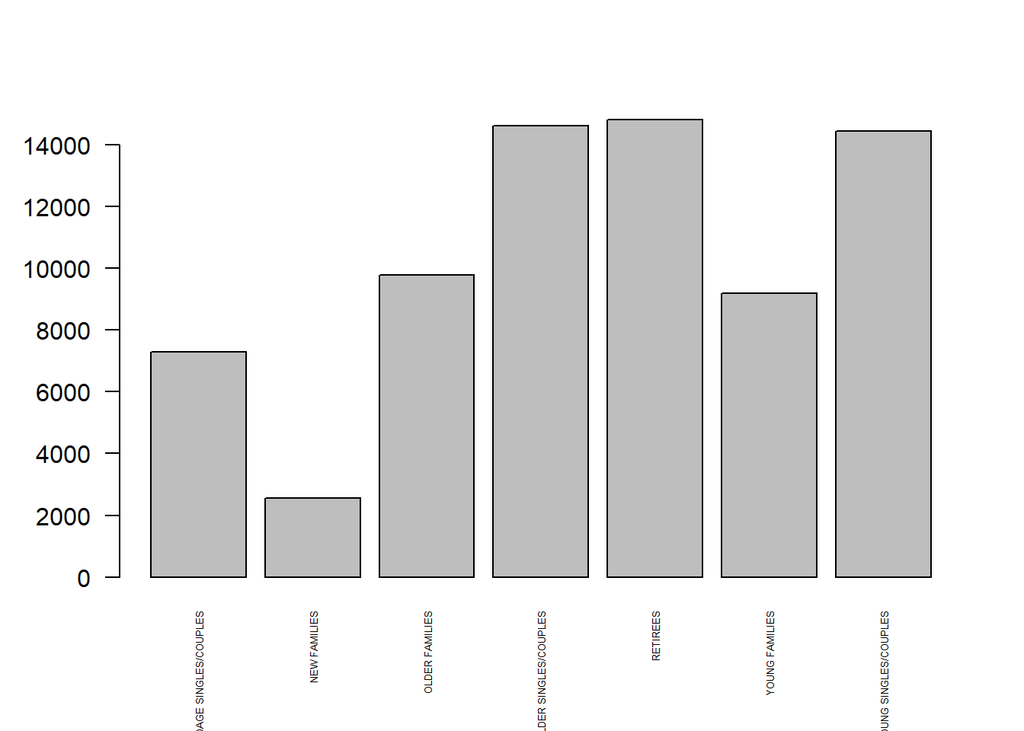

```r
#### Examining the values of LIFESTAGE and PREMIUM_CUSTOMER
barplot(table(customerData$LIFESTAG),
        cex.names = 0.4,
        las = 2)
```

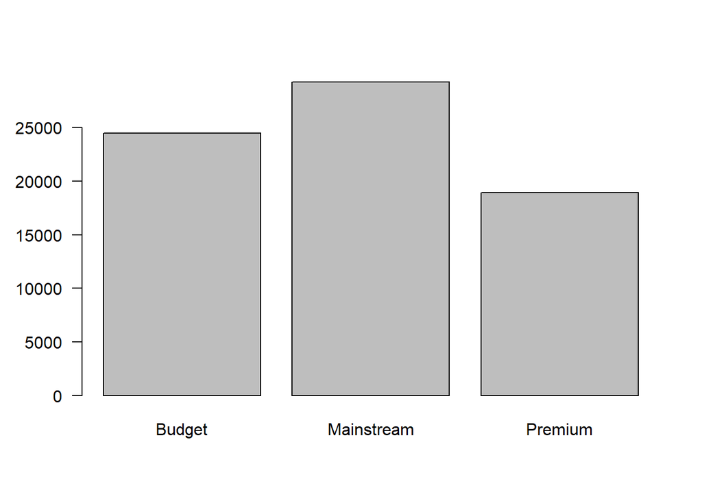

```r
barplot(table(customerData$PREMIUM_CUSTOMER),
        cex.names = 1,
        las = 1)
```

```r
#### Merge transaction data to customer data
data <- merge(transactionData, customerData, all.x = TRUE)
```

As the number of rows in `data` is the same as that of `transactionData`, we can be sure that no duplicates were created. This is because we created `data` by setting `all.x = TRUE` (in other words, a left join) which means take all the rows in `transactionData` and find rows with matching values in shared columns and then joining the details in these rows to the `x` or the first mentioned table. Let’s also check if some customers were not matched on by checking for nulls.

```r
sum(is.na(data$LYLTY_CARD_NBR))
```

```
## [1] 0
```

```r
sum(is.na(data$LIFESTAGE))
```

```
## [1] 0
```

```r
sum(is.na(data$PREMIUM_CUSTOMER))
```

```
## [1] 0
```

There are no nulls! So all our customers in the transaction data has been accounted for in the customer dataset.

Note that if you are continuing with Task 2, you may want to retain this dataset which you can write out as a csv

```r
fwrite(data, paste0(filePath,"QVI_data.csv"))
```

Data exploration is now complete!

## Data analysis on customer segments

Now that the data is ready for analysis, we can define some metrics of interest to the client:

- Who spends the most on chips (total sales), describing customers by lifestage and how premium their general purchasing behaviour is
- How many customers are in each segment
- How many chips are bought per customer by segment
- What’s the average chip price by customer segment We could also ask our data team for more information. Examples are:
- The customer’s total spend over the period and total spend for each transaction to understand what proportion of their grocery spend is on chips
- Proportion of customers in each customer segment overall to compare against the mix of customers who purchase chips

Let’s start with calculating total sales by LIFESTAGE and PREMIUM_CUSTOMER and plotting the split by these segments to describe which customer segment contribute most to chip sales.

```r
#### Total sales by LIFESTAGE and PREMIUM_CUSTOMER
sales_by_LP <- data %>% group_by(LIFESTAGE,PREMIUM_CUSTOMER) %>%
               summarize(total = sum(TOT_SALES))
```

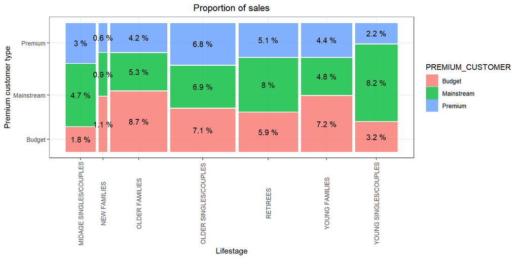

```r
#### Plot and label with proportion of sales
p1 <- ggplot(data = sales_by_LP) +
    geom_mosaic(aes(weight = total,
                    x = product(PREMIUM_CUSTOMER, LIFESTAGE),
                    fill = PREMIUM_CUSTOMER)) +
    labs(x="Lifestage", y = "Premium customer type", title = "Proportion of sales")+
    theme(axis.text.x = element_text(angle= 90, vjust =0.5))

#### Plot and label with proportion of sales
p1 + geom_text(data = ggplot_build(p1)$data[[1]],
              aes(x = (xmin + xmax)/2, y = (ymin + ymax)/2,
                  label = as.character(paste(round(.wt/sum(.wt),3)*100,"%")))
              )
```

Sales are coming mainly from Budget - older families, Mainstream - young singles/couples, and Mainstream - retirees.

Let’s see if the higher sales are due to there being more customers who buy chips.

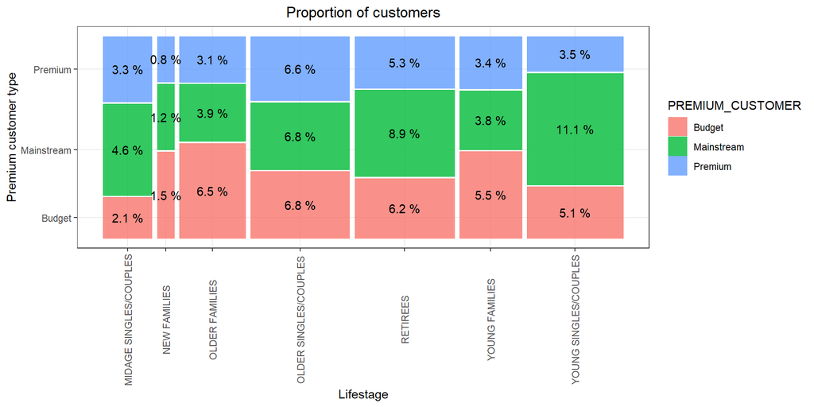

```r
#### Number of customers by LIFESTAGE and PREMIUM_CUSTOMER
numberCustomers_LP <- data[, .(customer = uniqueN(LYLTY_CARD_NBR)),
                           .(LIFESTAGE, PREMIUM_CUSTOMER)][order(-customer)]

#### Create plot
p2 <- ggplot(data = numberCustomers_LP) +
      geom_mosaic(aes(weight = customer, x = product(PREMIUM_CUSTOMER,LIFESTAGE),
                      fill = PREMIUM_CUSTOMER)) +
      labs(x = "Lifestage", y = "Premium customer type",
           title = "Proportion of customers") +
      theme(axis.text.x = element_text(angle = 90, vjust = 0.5))

#### Plot and label with proportion of customers
p2 + geom_text(data = ggplot_build(p2)$data[[1]],
                aes(x = (xmin + xmax)/2, y = (ymin + ymax)/2,
                label = as.character(paste(round(.wt/sum(.wt),3)*100,"%"))))
```

There are more Mainstream - young singles/couples and Mainstream - retirees who buy chips. This contributes to there being more sales to these customer segments but this is not a major driver for the Budget - Older families segment.

Higher sales may also be driven by more units of chips being bought per customer. Let’s have a look at this next.

```r
#### Average number of units per customer by LIFESTAGE and PREMIUM_CUSTOMER
units_by_LP <- data %>% group_by(LIFESTAGE,PREMIUM_CUSTOMER) %>%
               summarize(Total = sum(PROD_QTY))
```

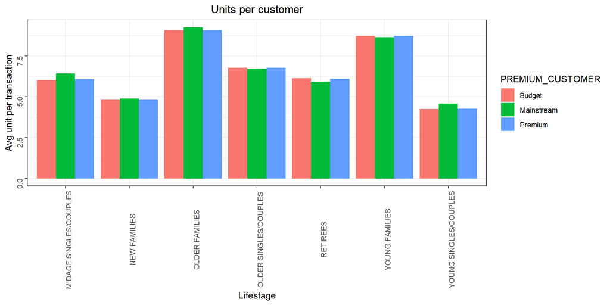

```r
average_unit.data <- merge(units_by_LP,numberCustomers_LP )
average_unit.data$average_unit_per_customer <- average_unit.data$Total/
                                               average_unit.data$customer
average_unit.data <- average_unit.data[,-c(3,4)]

#### Create plot
p3 <- ggplot(data = average_unit.data,
             aes(weight = average_unit_per_customer, x = LIFESTAGE,
                 fill = PREMIUM_CUSTOMER))+
      geom_bar(position = position_dodge())+
      labs(x = "Lifestage", y = "Avg unit per transaction",
           title = "Units per customer") +
      theme(axis.text = element_text(angle = 90, vjust = 0.5))
p3
```

Older families and young families in general buy more chips per customer.

Let’s also investigate the average price per unit chips bought for each customer segment as this is also a driver of total sales.

```r
#### Average price per unit by LIFESTAGE and PREMIUM_CUSTOMER
average_price.data <- merge(sales_by_LP,units_by_LP)

average_price.data$average_price_per_unit <- average_price.data$total/
                                             average_price.data$Total
average_price.data <- average_price.data[,-c(3,4)]
average_price.data
```

| LIFESTAGE | PREMIUM_CUSTOMER | average_price_per_unit |
| --- | --- | --- |
| MIDAGE SINGLES/COUPLES | Budget | 3.753878 |
| MIDAGE SINGLES/COUPLES | Mainstream | 3.994449 |
| MIDAGE SINGLES/COUPLES | Premium | 3.780823 |
| NEW FAMILIES | Budget | 3.931969 |
| NEW FAMILIES | Mainstream | 3.935887 |
| NEW FAMILIES | Premium | 3.886168 |
| OLDER FAMILIES | Budget | 3.747969 |
| OLDER FAMILIES | Mainstream | 3.736380 |
| OLDER FAMILIES | Premium | 3.717703 |
| OLDER SINGLES/COUPLES | Budget | 3.887529 |

[output cut: 11 more lines]

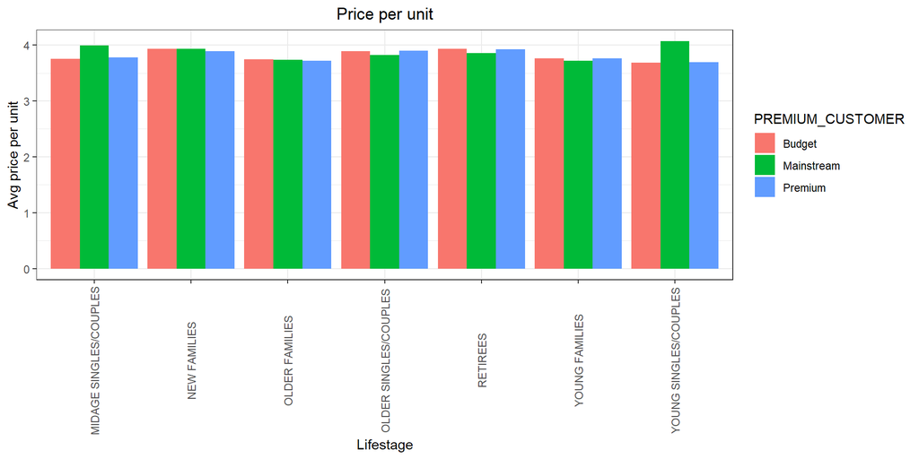

```r
#### Create plot
p4 <- ggplot(data = average_price.data,
             aes(weight = average_price_per_unit, x = LIFESTAGE ,
                 fill = PREMIUM_CUSTOMER)) +
      geom_bar(position = position_dodge()) +
      labs(x = "Lifestage" , y = "Avg price per unit",
           title = "Price per unit") +
      theme(axis.text.x = element_text(angle = 90, vjust = 0.5))
p4
```

Mainstream midage and young singles and couples are more willing to pay more per packet of chips compared to their budget and premium counterparts. This may be due to premium shoppers being more likely to buy healthy snacks and when they buy chips, this is mainly for entertainment purposes rather than their own consumption.

This is also supported by there being fewer premium midage and young singles and couples buying chips compared to their mainstream counterparts.

As the difference in average price per unit isn’t large, we can check if this difference is statistically different.

```r
#### Perform an independent t-test between mainstream vs premium and budget midage
#### and
#### young singles and couples
price_by_unit <- data[, price := TOT_SALES/PROD_QTY]
t.test(data[LIFESTAGE %in% c("YOUNG SINGLES/COUPLES", "MIDAGE SINGLES/COUPLES")
                           & PREMIUM_CUSTOMER == "Mainstream",
            price],
       data[LIFESTAGE %in% c("YOUNG SINGLES/COUPLES", "MIDAGE SINGLES/COUPLES")
                           & PREMIUM_CUSTOMER != "Mainstream",
            price],
       alternative = "greater")
```

```
##
## Welch Two Sample t-test
##
## data: data[LIFESTAGE %in% c("YOUNG SINGLES/COUPLES", "MIDAGE
SINGLES/COUPLES") & and data[LIFESTAGE %in% c("YOUNG SINGLES/COUPLES", "MIDAGE
SINGLES/COUPLES") & PREMIUM_CUSTOMER == "Mainstream", price] and
PREMIUM_CUSTOMER != "Mainstream", price]
## t = 37.624, df = 54791, p-value < 2.2e-16
## alternative hypothesis: true difference in means is greater than 0
## 95 percent confidence interval:
## 0.3187234 Inf
## sample estimates:
## mean of x mean of y
## 4.039786 3.706491
```

The t-test results in a p-value closed to 0, i.e. the unit price for mainstream, young and mid-age singles and couples ARE significantly higher than that of budget or premium, young and midage singles and couples.

## Deep dive into specific customer segments for insights

We have found quite a few interesting insights that we can dive deeper into. We might want to target customer segments that contribute the most to sales to retain them or further increase sales. Let’s look at Mainstream - young singles/couples. For instance, let’s find out if they tend to buy a particular brand of chips.

```r
#### Deep dive into Mainstream, young singles/couples
segment1 <- data[LIFESTAGE == "YOUNG SINGLES/COUPLES" & PREMIUM_CUSTOMER == "Mainstream",]
other <- data[!(LIFESTAGE == "YOUNG SINGLES/COUPLES" & PREMIUM_CUSTOMER == "Mainstream"),]

#### Brand affinity compared to the rest o the population
quantity_segment1 <- segment1[,sum(PROD_QTY)]
quantity_other <- other[,sum(PROD_QTY)]

quantity_segment1_by_brand <- segment1[,.(targetSegment = sum(PROD_QTY)/quantity_segment1)
                                       ,by=BRAND]
quantity_other_by_brand <- other[,.(other = sum(PROD_QTY)/quantity_other),by = BRAND]

brand_prop <- merge(quantity_segment1_by_brand,
                    quantity_other_by_brand)[,affinityBrand :=
                                               targetSegment/other][order(-affinityBrand)]
brand_prop
```

| BRAND | targetSegment | other | affinityBrand |
| --- | --- | --- | --- |
| Tyrrells | 0.031552795 | 0.025692464 | 1.2280953 |
| Twisties | 0.046183575 | 0.037876520 | 1.2193194 |
| Doritos | 0.122760524 | 0.101074684 | 1.2145526 |
| Kettle | 0.197984817 | 0.165553442 | 1.1958967 |
| Tostitos | 0.045410628 | 0.037977861 | 1.1957131 |
| Pringles | 0.119420290 | 0.100634769 | 1.1866703 |
| Cobs | 0.044637681 | 0.039048861 | 1.1431238 |
| Infzns | 0.064679089 | 0.057064679 | 1.1334347 |
| Thins | 0.060372671 | 0.056986370 | 1.0594230 |
| GrnWves | 0.032712215 | 0.031187957 | 1.0488733 |

[output cut: 10 more lines]

We can see that :

- Mainstream young singles/counples are 23% more likely to purchase Tyrrells chips compared to the rest of the population;
- Mainstream young singles/couples are 56% less likely to purchase Burger Ringers compared to the rest of the population.

Let’s also find out if our target segment tends to buy larger packs of chips.

```r
#### Preferred pack size compared to the rest of the population
quantity_segment1_by_pack <- segment1[,.(targetSegment = sum(PROD_QTY)/quantity_segment1)
                                      , by = PACK_SIZE]
quantity_other_by_pack <- other[,.(other = sum(PROD_QTY)/quantity_other),by = PACK_SIZE]

pack_prop <- merge(quantity_segment1_by_pack,
                   quantity_other_by_pack)[,affinityPack := targetSegment/other
                                          ][order(-affinityPack)]
pack_prop
```

| PACK_SIZE | targetSegment | other | affinityPack |
| --- | --- | --- | --- |
| 270 | 0.031828847 | 0.025095929 | 1.2682873 |
| 380 | 0.032160110 | 0.025584213 | 1.2570295 |
| 330 | 0.061283644 | 0.050161917 | 1.2217166 |
| 134 | 0.119420290 | 0.100634769 | 1.1866703 |
| 110 | 0.106280193 | 0.089791190 | 1.1836372 |
| 210 | 0.029123533 | 0.025121265 | 1.1593180 |
| 135 | 0.014768806 | 0.013075403 | 1.1295106 |
| 250 | 0.014354727 | 0.012780590 | 1.1231662 |
| 170 | 0.080772947 | 0.080985964 | 0.9973697 |
| 150 | 0.157598344 | 0.163420656 | 0.9643722 |

[output cut: 10 more lines]

It looks like Mainstream young singles/couples are 27% more likely to purchase a 270g pack of chips compared to the rest of the population but let’s dive into what brands sell this pack size.

```r
table(data[PACK_SIZE == 270, "PROD_NAME"])
```

```
##
## Twisties Cheese     270g     Twisties Chicken270g
##                     3115                     3170
```

Twisties are the only brand offereint 270g packs and so this may instead be reflectin a higher likelihood of purchasing Twisties.